# Reproducible Research: Peer Assignment 2

Scott Hansen

Wednesday, March 04, 2016

# Data Preparation

## Initial Settings

```r
x<-c("R.utils", "ggplot2", "lubridate", "plyr", "gridExtra")

lapply(x, library, character.only=TRUE)
```

## Load Data

If the data is not already downloaded in the working directory, we will attempt to retrieve and unzip the file from the internet

```r
if (!"repdata-data-StormData.csv.bz2" %in% dir(".")) {
    print("File Not Found... Attempting to download")
    download.file("http://d396qusza40orc.cloudfront.net/repdata%2Fdata%2FStormData.csv.bz2", destfile = "repdata-data-StormData.csv.bz2")
    bunzip2("repdata-data-StormData.csv.bz2", overwrite=T, remove=F)
}
```

### Load Variable

Load and investigate the data set. Cache is turned on to improve performance.

```r
  if(!"StormData" %in% ls())
  {
    StormData<-read.csv("repdata-data-StormDatarepdata-data-StormData.csv", stringsAsFactors = FALSE)
  }
  dim(StormData)
```

```
## [1] 902297     37
```

```r
  head(StormData, n=1)
```

```
##   STATE__          BGN_DATE BGN_TIME TIME_ZONE COUNTY COUNTYNAME STATE
## 1       1 4/18/1950 0:00:00     0130       CST     97     MOBILE    AL
##    EVTYPE BGN_RANGE BGN_AZI BGN_LOCATI END_DATE END_TIME COUNTY_END
## 1 TORNADO         0                                               0
##   COUNTYENDN END_RANGE END_AZI END_LOCATI LENGTH WIDTH F MAG FATALITIES
## 1         NA         0                        14   100 3   0          0
##   INJURIES PROPDMG PROPDMGEXP CROPDMG CROPDMGEXP WFO STATEOFFIC ZONENAMES
## 1       15      25          K       0
##   LATITUDE LONGITUDE LATITUDE_E LONGITUDE_ REMARKS REFNUM
## 1     3040      8812       3051       8806              1
```

```r
  str(StormData)
```

```
## 'data.frame':    902297 obs. of  37 variables:
##  $ STATE__   : num  1 1 1 1 1 1 1 1 1 1 ...
##  $ BGN_DATE  : chr  "4/18/1950 0:00:00" "4/18/1950 0:00:00" "2/20/1951 0:00:00" "6/8/1951 0:00:00" ...
##  $ BGN_TIME  : chr  "0130" "0145" "1600" "0900" ...
##  $ TIME_ZONE : chr  "CST" "CST" "CST" "CST" ...
##  $ COUNTY    : num  97 3 57 89 43 77 9 123 125 57 ...
##  $ COUNTYNAME: chr  "MOBILE" "BALDWIN" "FAYETTE" "MADISON" ...
##  $ STATE     : chr  "AL" "AL" "AL" "AL" ...
##  $ EVTYPE    : chr  "TORNADO" "TORNADO" "TORNADO" "TORNADO" ...
##  $ BGN_RANGE : num  0 0 0 0 0 0 0 0 0 0 ...
##  $ BGN_AZI   : chr  "" "" "" "" ...
##  $ BGN_LOCATI: chr  "" "" "" "" ...
##  $ END_DATE  : chr  "" "" "" "" ...
##  $ END_TIME  : chr  "" "" "" "" ...
##  $ COUNTY_END: num  0 0 0 0 0 0 0 0 0 0 ...
```

[output cut: 23 more lines]

## Investigate Data set

Histogram of storm events

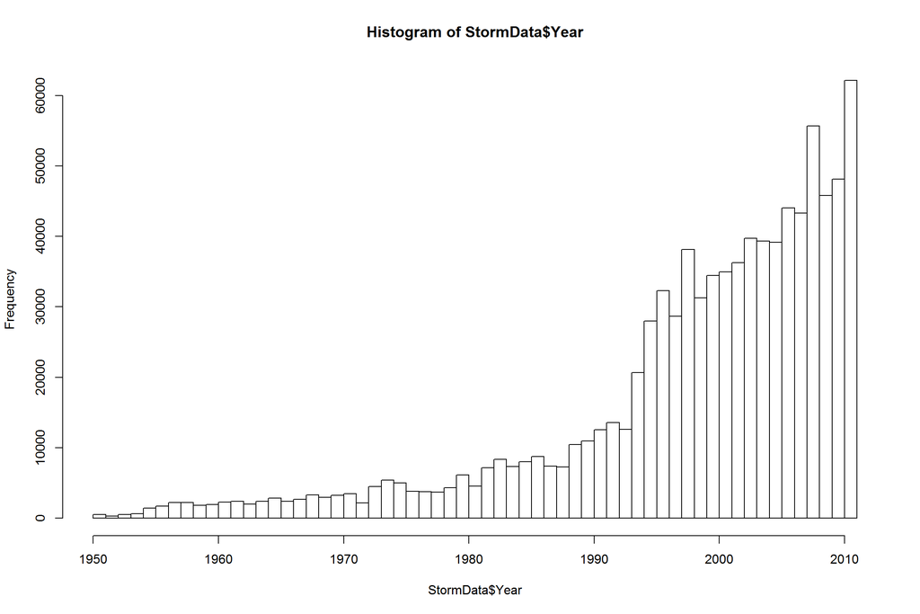

```r
  StormData$Year<- as.numeric(year(mdy_hms(StormData$BGN_DATE)))
  hist(StormData$Year, breaks=61)
```

## Chosing the best subset of the data It is unlikely that there were significantly more storms starting around 1990. More likely record keeping improved; so the analysis will focus only on weather events after 1990

```r
  StormData<-StormData[StormData$Year >= 1990, ]
  dim(StormData)
```

```
## [1] 751740     38
```

## Build Summary Statistics

### Fatalities

```r
  Fatalities<-aggregate(FATALITIES~EVTYPE, data=StormData, sum)
  Fatalities<-head(arrange(Fatalities, Fatalities$FATALITIES, decreasing=TRUE), n=10)
```

### Injuries

```r
  Injuries<-aggregate(INJURIES~EVTYPE, data=StormData, sum)
  Injuries<-head(arrange(Injuries, Injuries$INJURIES, decreasing=TRUE), n=10)
```

### Economic Impact

The economic impact cannot be directly read from the data fram. Based on the metadata about the data set, there is an exponential multiplier that must be applied.

- Summarize Property and Crop damage
- Eliminate Bad Exponential exponential multipliers

```r
  PropDamage<- aggregate(PROPDMG~EVTYPE+PROPDMGEXP, data=StormData, sum)
  PropDamage<- PropDamage[PropDamage$PROPDMGEXP %in% c("K", "M", "B"),]

  CropDamage<- aggregate(CROPDMG~EVTYPE+CROPDMGEXP, data=StormData, sum)
  CropDamage<- CropDamage[CropDamage$CROPDMGEXP %in% c("K", "M", "B"),]

  for (i in 1:nrow(CropDamage))
    {

    if (CropDamage$CROPDMGEXP[i]=="K") {CropDamage$CROPDMG[i]= CropDamage$CROPDMG[i]*1000}
    if (CropDamage$CROPDMGEXP[i]=="M") {CropDamage$CROPDMG[i]= CropDamage$CROPDMG[i]*1000000}
    if (CropDamage$CROPDMGEXP[i]=="B") {CropDamage$CROPDMG[i]= CropDamage$CROPDMG[i]*1000000000}
    }

  for (i in 1:nrow(PropDamage))
    {

    if (PropDamage$PROPDMGEXP[i]=="K") {PropDamage$PROPDMG[i]= PropDamage$PROPDMG[i]*1000}
    if (PropDamage$PROPDMGEXP[i]=="M") {PropDamage$PROPDMG[i]= PropDamage$PROPDMG[i]*1000000}
    if (PropDamage$PROPDMGEXP[i]=="B") {PropDamage$PROPDMG[i]= PropDamage$PROPDMG[i]*1000000000}
    }
```

- Create a summary based on event type
- Order the summarized data set and select the top 10 storm event types
- Print results

```r
  CropDamage<-aggregate(CROPDMG~EVTYPE, data=CropDamage, sum)
  CropDamage<-head(arrange(CropDamage, CropDamage$CROPDMG, decreasing=TRUE), n=10)

  PropDamage<-aggregate(PROPDMG~EVTYPE, data=PropDamage, sum)
  PropDamage<-head(arrange(PropDamage, PropDamage$PROPDMG, decreasing=TRUE), n=10)
```

# Presentation of Results

This analysis will break the analysis of weatherevents into 2 part:

- Human cost
- Economic costs

## Presenting the human cost of weather

The top 10 weather events for fatalities are:

```r
  Fatalities
```

```
##            EVTYPE FATALITIES
## 1  EXCESSIVE HEAT       1903
## 2         TORNADO       1752
## 3     FLASH FLOOD        978
## 4            HEAT        937
## 5       LIGHTNING        816
## 6           FLOOD        470
## 7     RIP CURRENT        368
## 8       TSTM WIND        327
## 9       HIGH WIND        248
## 10      AVALANCHE        224
```

The top 10 weather events for Injuries are:

```r
  Injuries
```

```
##               EVTYPE INJURIES
## 1            TORNADO    26674
## 2              FLOOD     6789
## 3     EXCESSIVE HEAT     6525
## 4          LIGHTNING     5230
## 5          TSTM WIND     5022
## 6               HEAT     2100
## 7          ICE STORM     1975
## 8        FLASH FLOOD     1777
## 9  THUNDERSTORM WIND     1488
## 10      WINTER STORM     1321
```

This can be best presented in a bar graph

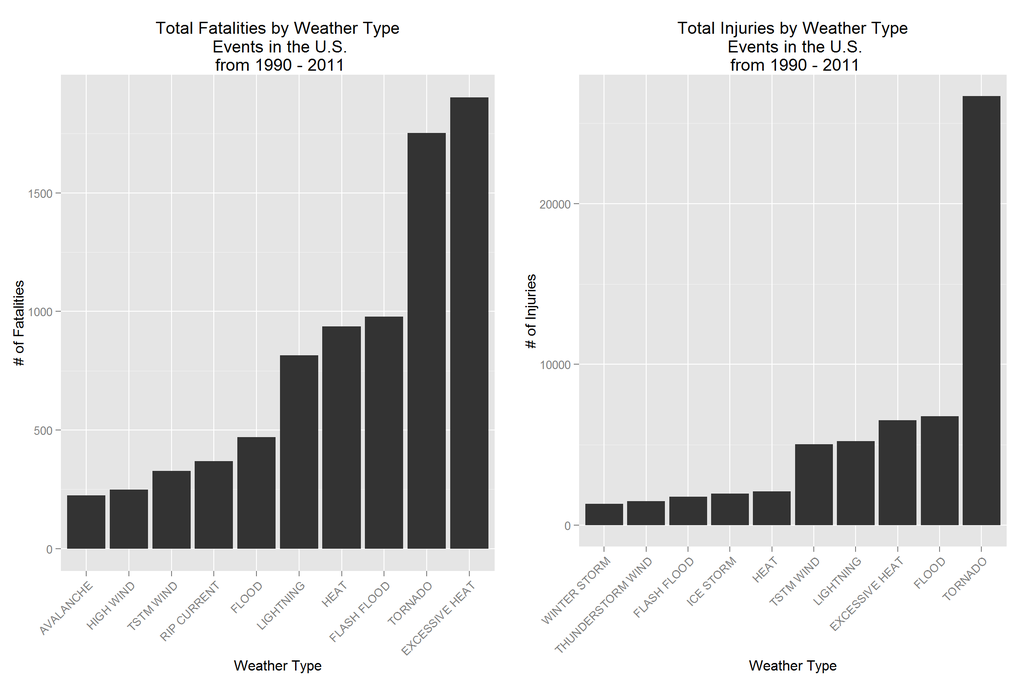

```r
fatalitiesPlot <- ggplot(Fatalities, aes(reorder(EVTYPE, FATALITIES), FATALITIES)) +
  geom_bar(stat="identity") +
    scale_y_continuous("# of Fatalities") +
    theme(axis.text.x = element_text(angle = 45,
    hjust = 1)) + xlab("Weather Type") +
    ggtitle("Total Fatalities by Weather Type\n Events in the U.S.\n from 1990 - 2011")
injuriesPlot <- ggplot(Injuries, aes(reorder(EVTYPE, INJURIES), INJURIES)) +
  geom_bar(stat="identity") +
    scale_y_continuous("# of Injuries") +
    theme(axis.text.x = element_text(angle = 45,
    hjust = 1)) + xlab("Weather Type") +
    ggtitle("Total Injuries by Weather Type\n Events in the U.S.\n from 1990 - 2011")
grid.arrange(fatalitiesPlot, injuriesPlot, ncol = 2)
```

Based on the above histograms, we find that excessive heat and tornado cause most fatalities; tornato causes most injuries in the United States from 1990 to 2011.

## Presenting the economic cost of weather

The top 10 weather events for Property damage are:

```r
  PropDamage
```

```
##               EVTYPE      PROPDMG
## 1              FLOOD 144657709800
## 2  HURRICANE/TYPHOON  69305840000
## 3        STORM SURGE  43323536000
## 4            TORNADO  30447015310
## 5        FLASH FLOOD  16140811510
## 6               HAIL  15727366720
## 7          HURRICANE  11868319010
## 8     TROPICAL STORM   7703890550
## 9       WINTER STORM   6688497250
## 10         HIGH WIND   5270046260
```

The top 10 weather events for Crop damage are:

```r
  CropDamage
```

```
##               EVTYPE     CROPDMG
## 1            DROUGHT 13972566000
## 2              FLOOD  5661968450
## 3        RIVER FLOOD  5029459000
## 4          ICE STORM  5022113500
## 5               HAIL  3025537450
## 6          HURRICANE  2741910000
## 7  HURRICANE/TYPHOON  2607872800
## 8        FLASH FLOOD  1421317100
## 9       EXTREME COLD  1292973000
## 10      FROST/FREEZE  1094086000
```

This can be best presented in a bar graph

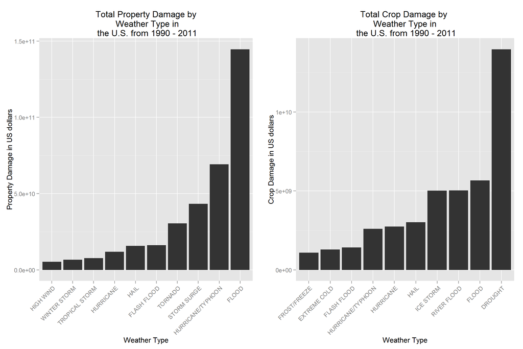

```r
propertyPlot <- ggplot(PropDamage, aes(reorder(EVTYPE, PROPDMG), PROPDMG)) +
  geom_bar(stat="identity") +
  theme(axis.text.x = element_text(angle = 45, hjust = 1)) + scale_y_continuous("Property Damage in US dollars")+
  xlab("Weather Type") + ggtitle("Total Property Damage by\n Weather Type in\n the U.S. from 1990 - 2011")


cropPlot<- ggplot(CropDamage, aes(reorder(EVTYPE, CROPDMG), CROPDMG)) +
  geom_bar(stat="identity") +
    theme(axis.text.x = element_text(angle = 45, hjust = 1)) + scale_y_continuous("Crop Damage in US dollars") +
    xlab("Weather Type") + ggtitle("Total Crop Damage by \nWeather Type in\n the U.S. from 1990 - 2011")

grid.arrange(propertyPlot, cropPlot, ncol = 2)
```

Based on the above histograms, we find that flood and hurricane/typhoon cause most property damage; drought and flood causes most crop damage in the United States from 1990 to 2011.

# Conclusion

From these data, we found that excessive heat and tornado are most harmful with respect to population health, while flood, drought, and hurricane/typhoon have the greatest economic consequences.